# Predictive modeling: Advanced Regression Techniques

## 5. Modelling and predicting.

Since predicting continuous values such as `SalePrice` in our case is purely a regression problem I am going to try fitting the following models:

- **Linear Regression**
- **Elastic-Net Regularized Linear Regression**
- **Simple random forest**
- **Gradient boosting**

While fitting the models I will be estimating how accurately they perform based on **RMSE** in practice using **10-fold cross-validation** and averaging out of sample error. That will be then repeated **5 times** to give more precise estimate of the true out of sample error. It will also produce exact same cross-validation folds for each model to make fair comparison.

To be able to fit the above listed models by specifying the **method** option and perform **cross validation** on them *caret package* will be used as it provides a common interface to various predictive models.

- **Linear Regression model.**

**Preprocessing steps.**

Here centering and scaling has been performed so that the units of the regression coefficients are the same.

Since there are low variance and correlated variables in the data set I am going to apply **PCA** and remove **zero and near zero variance predictors** in order to reduce dimensionality and create a single set of high variance, perpendicular (perfectly uncorrelated) predictors.

The **results** of the linear regression model are as follows:

```
## Created from 1678 samples and 184 variables
##
## Pre-processing:
##   - centered (131)
##   - ignored (0)
##   - principal component signal extraction (131)
##   - removed (53)
##   - scaled (131)
##
## PCA needed 68 components to capture 95 percent of the variance
```

```
##   intercept    RMSE  Rsquared        MAE      RMSESD RsquaredSD
## 1      TRUE 0.11177 0.9063358 0.08328145 0.008412923   0.017306
##         MAESD
## 1 0.005402335
```

- **Elastic-Net Regularized Linear Regression model.**

**Preprocessing steps.**

Centering and scaling has been performed again so that the units of the regression coefficients are the same.

No PCA this time as elastic-net has built-in variable selection. As it is the combination of Ridge and Lasso, by tuning `alpha` and `lambda` hyperparameters it penalizes both the number of non-zero coefficients and absolute magnitude of coefficients which will help better handle collinearity in order to find a parsimonious model.

**Tuning grid.**

For single value of alpha all values of lambda are fit simultaneously. This grid explores 10 `lambda` values, from 0.0001 to 0.01 and 20 `alpha` values between 0 and 1. I chose such low values of `lambda` because in this case higher values increase **RMSE**.

Based on the smallest mean of **RMSE** (0.1010849) value the optimal model was selected with hyperparameters of `alpha` = 0.2631579 and `lambda` = 0.0023.

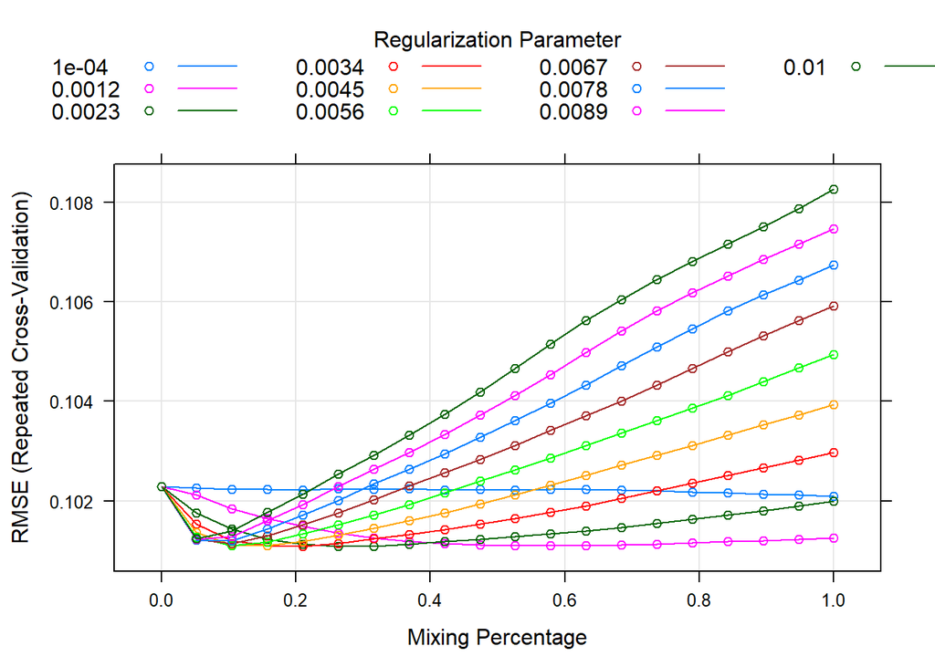

```
##       alpha lambda      RMSE  Rsquared        MAE      RMSESD RsquaredSD
## 1 0.2631579 0.0023 0.1010849 0.9232218 0.07535492 0.007526839 0.01494848
##         MAESD
## 1 0.004908611
```

- **Simple random forest model.**

**Preprocessing steps.**

No need to center and scale as Random Forests are based on tree partitioning algorithms and not on coefficients obtained in general regression strategies.

The reason why I am going to use it is due to its robustness to correlated predictors and the ability to handle high-dimensional data without variable selection.

Rather than using the classic random Forest package, I’ll be using the *ranger package*, which is a re-implementation of random Forest and is said to be faster.

**Tuning.**

The **results** are as follows:

```
##   mtry splitrule min.node.size      RMSE  Rsquared        MAE      RMSESD
## 1   62  variance             5 0.1118944 0.9119417 0.07976847 0.007502088
##   RsquaredSD       MAESD
## 1 0.01560828 0.004290847
```

As fitting and tuning random forest model is quite time consuming hence only the final model with “the best” grid search was included in the project.

- **Gradient boosting model.**

I am going to try to boost the accuracy of the random tree model by applying boosting algorithm that defines a loss function and minimizes it.

**Preprocessing steps.**

Since gradient boosting is based on decision tree so there is no need to center and scale.

**Tuning grid.**

The optimal tuning grid that minimizes **RMSE** was set as follows:

- the number of iterations, i.e. trees `n.trees` to 209-219;
- the complexity of the tree `interaction.depth` to 7;
- the learning rate or `shrinkage` to 0.1;
- the minimum number of training set samples in a node `n.minobsinnode` to 22

**Tuning results:**

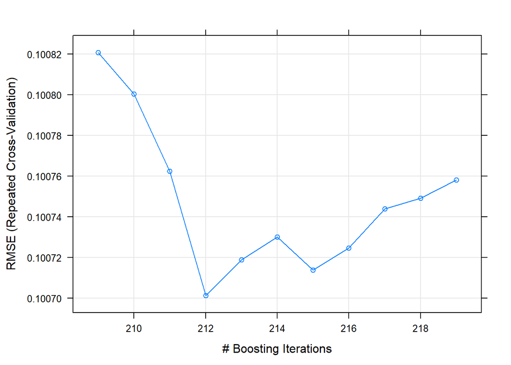

```
##   shrinkage interaction.depth n.minobsinnode n.trees      RMSE  Rsquared
## 1       0.1                 7             22     212 0.1007012 0.9240502
##          MAE      RMSESD RsquaredSD       MAESD
## 1 0.07393292 0.006643749 0.01282589 0.004362225
```

- **Comparing and choosing the model.**

To assess which of the four models is the best for the given data set I am going to use *resamples()* function.

```
##
## Call:
## summary.resamples(object = resamples)
##
## Models: LM_model, Elastic_net_model, Random_f, GBM
## Number of resamples: 50
##
## MAE
##                         Min.    1st Qu.     Median       Mean    3rd Qu.
## LM_model          0.07128399 0.07982939 0.08283884 0.08328145 0.08743720
## Elastic_net_model 0.06620606 0.07177747 0.07475199 0.07535492 0.07929916
## Random_f          0.06928991 0.07732176 0.07988029 0.07976847 0.08145419
## GBM               0.06522763 0.07072462 0.07387216 0.07393292 0.07656636
##                         Max. NA's
## LM_model          0.09284001    0
## Elastic_net_model 0.08532457    0
## Random_f          0.09072787    0
## GBM               0.08509322    0
##
## RMSE
##                         Min.    1st Qu.    Median      Mean   3rd Qu.
## LM_model          0.09540845 0.10596926 0.1123074 0.1117700 0.1179503
## Elastic_net_model 0.08428989 0.09523650 0.1003942 0.1010849 0.1078588
## Random_f          0.09036576 0.10802681 0.1124333 0.1118944 0.1163622
## GBM               0.08984786 0.09458298 0.1018693 0.1007012 0.1062417
##                        Max. NA's
## LM_model          0.1312309    0
## Elastic_net_model 0.1173945    0
## Random_f          0.1278276    0
## GBM               0.1162834    0
##
## Rsquared
##                        Min.   1st Qu.    Median      Mean   3rd Qu.
## LM_model          0.8667886 0.8986454 0.9043552 0.9063358 0.9180469
## Elastic_net_model 0.8863210 0.9142911 0.9221019 0.9232218 0.9329225
## Random_f          0.8608342 0.9008972 0.9142391 0.9119417 0.9224980
## GBM               0.8961135 0.9151449 0.9243748 0.9240502 0.9330571
##                        Max. NA's
## LM_model          0.9346820    0
## Elastic_net_model 0.9568106    0
## Random_f          0.9393474    0
## GBM               0.9460941    0
```

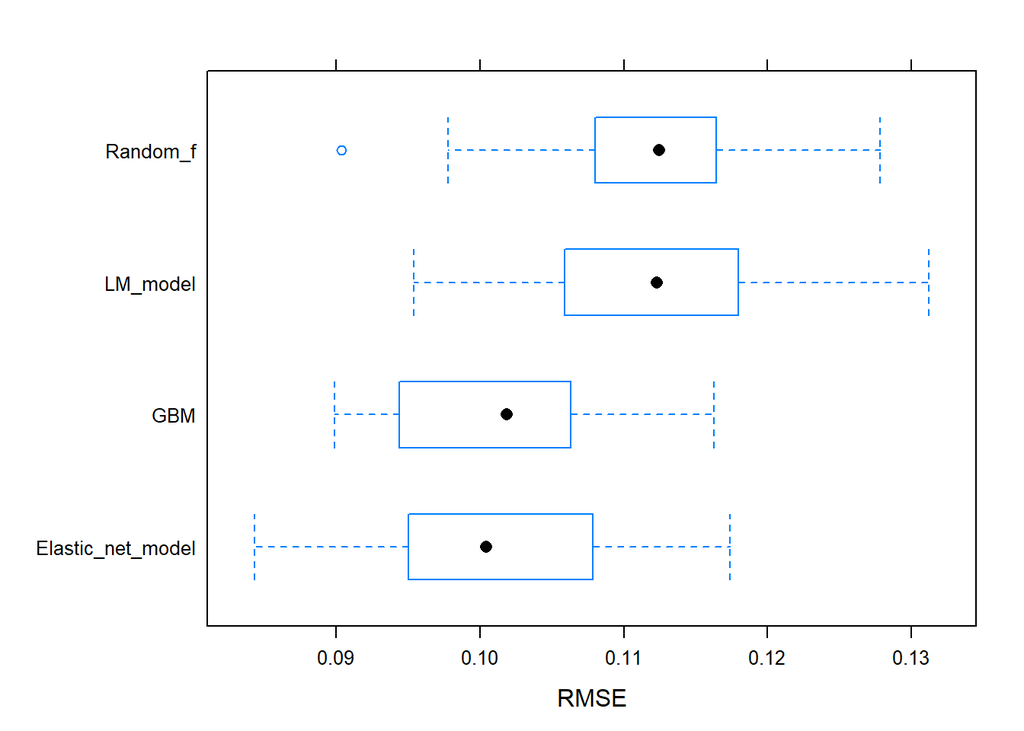

As a result of regularization and boosting both **Elastic net** and ***GBM** models yield to better results. Based on the lowest median **RMSE** `Elastic_net_model` has been chosen as the final one.

- **Predicting**

Predicting logged `SalePrice` on unseen data results in **RMSE** equal to 0.1024034 or $ 18100.87 which is higher than the median, but within the IQR of the performance statistics.

**Logged predictions RMSE**:

```
## [1] 0.1024034
```

**Root-mean-square error in US dollars:**

```
## [1] 18100.87
```

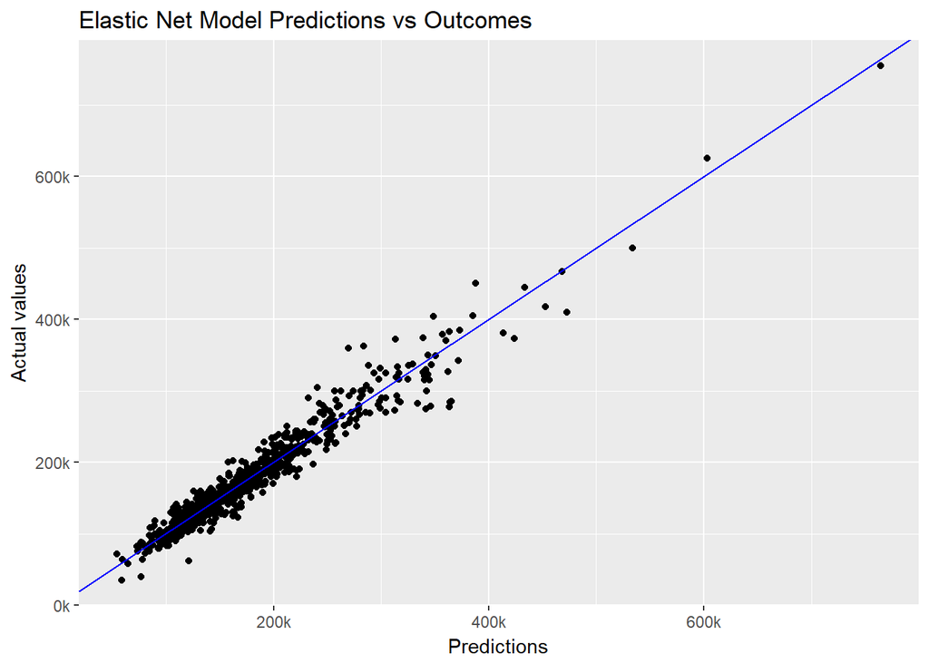

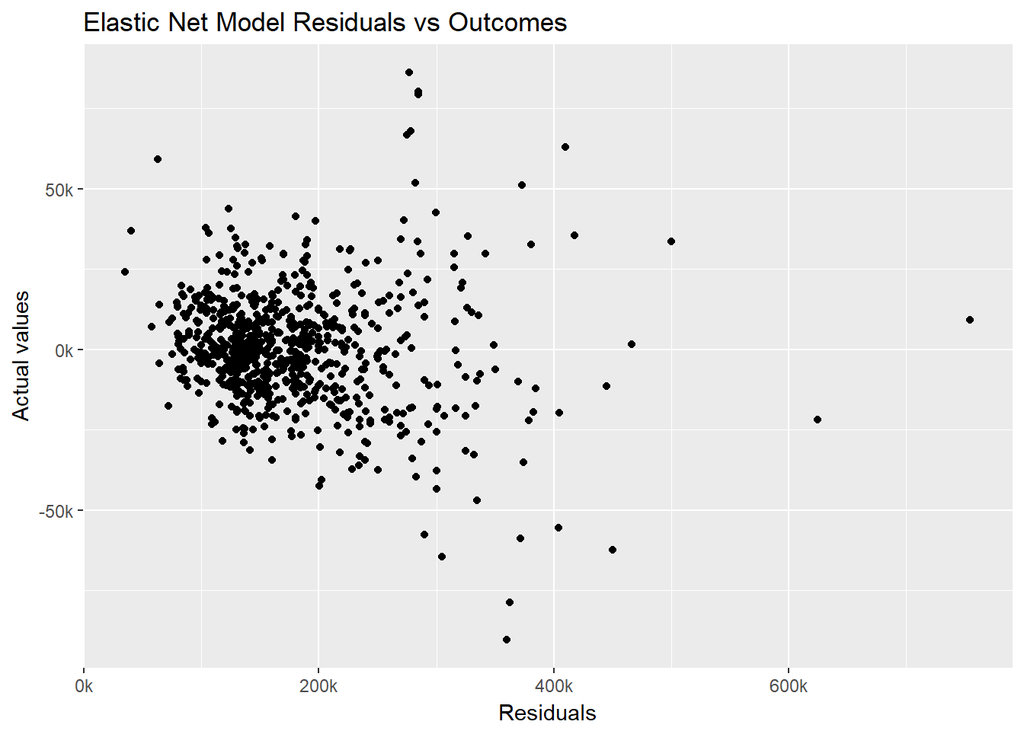

## Conclusions.

As results of the project we have the model to predict housing prices in Iowa, Ames for the properties sold under normal sale conditions as well as the features that influence the price the most.

**The features in the order of importance:**

- `Gr.Liv.Area`
- `Total.Bsmt.SF`
- `Garage.Area`
- `Overall.Qual`
- `New_Neighborhood`
- `Lot.Area`
- `BsmtFin.SF.1`
- `Fireplace.Qu`
- `Fireplaces`
- `TotRms.AbvGrd`
- `Garage.Cars`
- `House.age`
- `Remod.age`